# Stability Assessment of Results from Supervised Statistical Learning

Michel Philipp, Thomas Tusch, Kurt Hornik, and Carolin Strobl

2017-11-20

## Introduction

The R package **stablelearner** implements a general framework for investigating and quantifying the stability of analytic results from supervised statistical learning, both when a data set (as in real world supervised learning problems) or the data-generating process (DGP; as in simulation studies) is available. The framework can support data analysts in measuring the stability of a single analysis result, in choosing the most stable algorithm among a set of candidates, or in selecting tuning parameters with respect to stability. Stability can also be used as an additional performance criterion in benchmark experiments.

### Getting started

In every new R session **stablelearner** must be loaded via

```r
library("stablelearner")
```

The documentation of the package (with help pages for each function) can be accessed via

```r
help(package = "stablelearner")
```

### The *Titanic* example

For the demonstration of the stability assessment procedure the well-known *Titanic* data set is used (see `?titanic` for a detailed description of the data set). The data set is available in **stablelearner** and can be activated using

```r
data("titanic")
```

The goal is to predict the survival of the passengers during the sinking of the RMS Titanic in 1912 through passenger characteristics that are given by seven predictor variables of mixed types (numeric, unordered and ordered categorical). Using the symbolic formulation in R, the model is defined by

```r
fmla <- survived ~ gender + age + class + embarked + fare + sibsp + parch
```

For our purpose, the data set is reduced to the passengers on the RMS Titanic (i.e., crew members are excluded from the data set) and further pre-processing is applied.

```r
titanic_pax <- subset(titanic, class %in% c("1st", "2nd", "3rd"))
titanic_pax$sibsp <- as.numeric(titanic_pax$sibsp)
titanic_pax$parch <- as.numeric(titanic_pax$parch)
titanic_pax <- titanic_pax[,all.vars(fmla)]
titanic_pax <- titanic_pax[complete.cases(titanic_pax),]
titanic_pax <- droplevels(titanic_pax)
```

In the introduction presented in the next section, the model will be trained using conditional inference trees from **partykit**. However, **stablelearner** also works with many other statistical learning methods that are implemented in or available through R.

## Stability assessment for a single learner

The procedure to measure the stability of results contains two steps. First, **partykit**, that provides the functions to fit conditional inference trees, is loaded and a result is generated using the *Titanic* data set and the formula specified above.

```r
library("partykit")
res1 <- ctree(fmla, data = titanic_pax)
```

Then, the resulting model object is passed to the function `stability()` for the stability assessment (the default settings are used if nothing else is specified).

```r
stab <- stability(res1)
```

Parallelization may be utilized through the argument `cores` for multicore computation based on **parallel**. Please note, that parallelization only works with platforms that support this.

A summary of the sampling and the estimated similarity values can now be shown via

```r
summary(stab)
```

```
##
## Call:
## ctree(formula = fmla, data = titanic_pax)
##
## Sampler:
## B = 500
## Resampling method = Bootstrap sampling with 100.0% data
## Evaluation method = OOB
##
## Sampling summary:
##                             avg  min  max
## Learning sample size   1289.000 1289 1289
## Learning overlap        516.126  484  553
## Evaluation sample size  174.876  141  211
## Evaluation overlap        0.000    0    0
##
## Similarity summary:
##
## , , Total variation distance (reversed)
##
##            5%    25%   50%   75%   95%
## constparty 0.898 0.913 0.926 0.941 0.955
```

The default similarity measure for classification problems is the total variation distance (TVD). The values are automatically reversed such that higher values indicate higher stability. If not desired, this can be suppressed by `summary(stab, reverse = FALSE)`.

## Stability assessment for several learners

Typically, users are interested in either selecting the algorithm with the highest stability or tuning the parameters of an algorithm with respect to stability for a given data set. Both problems can be addressed by passing several results to the `stability()` function.

### Selecting an algorithm with respect to stability

The next example demostrates the comparison of different recursive partitioning algorithms for a given model and data set. The competing algorithms are conditional inference trees (the result generated before will be re-used) and two different implementations of classification and regression trees (CART). The default settings were used for all implementations and no pruning for the CART implementations.

First, the packages that provide the functions to train the data with the algorithms of interest must be loaded to the current R session:

```r
library("rpart")
library("tree")
```

Next, for each algorithm an initial result must be generated for the same model and data set:

```r
res2 <- rpart(fmla, data = titanic_pax)
res3 <- tree(fmla, data = titanic_pax)
```

The stability can be assessed jointly by passing all objects to the `stability()` function. For comparability, a seed may be set via the `control` argument, such that the stability of each result is assessed using the same resampled data sets.

```r
stab_alg <- stability(res1, res2, res3, control = stab_control(seed = 1234))
```

Again, the summary is shown via the generic function `summary()`. Optionally, labels may be passed via the argument `names` for a better recognition of the results in its output.

```r
summary(stab_alg, names = c("ctree", "rpart", "tree"))
```

```
##
## Call:
## ctree(formula = fmla, data = titanic_pax)
## rpart(formula = fmla, data = titanic_pax)
## tree(formula = fmla, data = titanic_pax)
##
## Sampler:
## B = 500
## Resampling method = Bootstrap sampling with 100.0% data
## Evaluation method = OOB
##
## Sampling summary:
##                             avg  min  max
## Learning sample size   1289.000 1289 1289
## Learning overlap        515.702  480  548
## Evaluation sample size  174.470  143  204
## Evaluation overlap        0.000    0    0
##
## Similarity summary:
##
## , , Total variation distance (reversed)
##
##       5%    25%   50%   75%   95%
## ctree 0.896 0.914 0.928 0.940 0.957
## rpart 0.882 0.905 0.928 0.948 0.966
## tree  0.892 0.917 0.932 0.944 0.962
```

The similarity distribution may be illustrated graphically. A simple plot can be generated with the generic standard R plotting function:

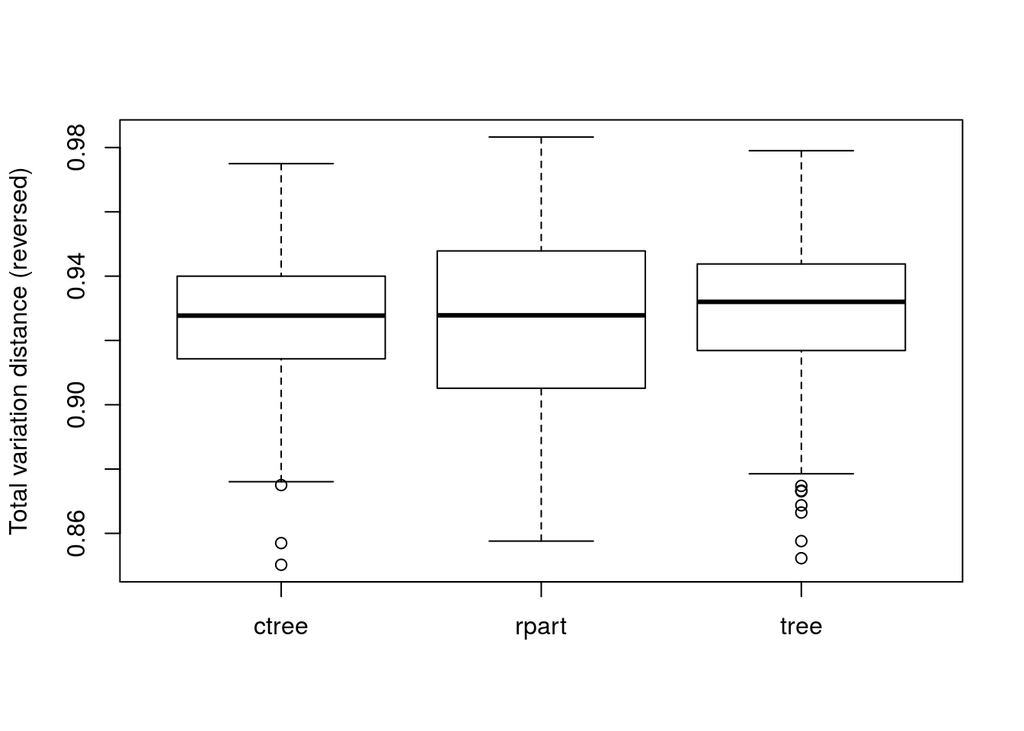

```r
boxplot(stab_alg, names = c("ctree", "rpart", "tree"))
```

For comparison, the accuracy may be computed and illustrated. Available accuracy measures for classification problems are the Accuracy (percentage of observations on the diagonal of the contingency table), the Kappa statistic, the Rand index and the corrected Rand index. For more details see `?e1071::classAgreement`.

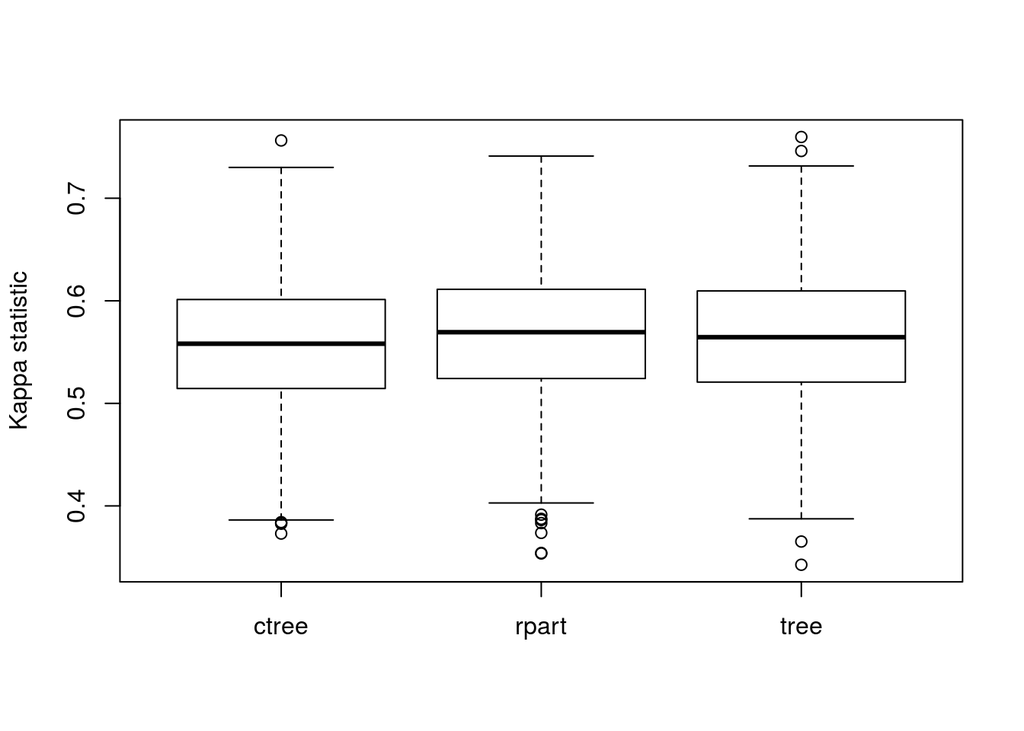

```r
acc_alg <- accuracy(stab_alg)
boxplot(acc_alg, names = c("ctree", "rpart", "tree"), ylab = "Kappa statistic")
```

### Parameter tuning with respect to stability

As before the function `stability()` can be used for comparing results that where generated using different values for a tuning parameters of a specific algorithm. The next example demostrates how to find the optimal number of hidden units in a single-hidden-layer neural network with respect to stability.

First, load the package **nnet** that provides the function to fit a single-hidden-layer neural network in and fit several results with different value for the tuning parameter.

```r
library("nnet")
res1 <- nnet(fmla, data = titanic_pax, size = 1, trace = FALSE)
res2 <- nnet(fmla, data = titanic_pax, size = 2, trace = FALSE)
res3 <- nnet(fmla, data = titanic_pax, size = 3, trace = FALSE)
...
tune <- list(res1, res2, res3, ...)
```

Alternatively one can use the `tuner()` function and define the range of values for the tuning parameter via the argument `tunerange`.

```r
library("nnet")
tune <- tuner("nnet", formula = fmla, data = titanic_pax, trace = FALSE,
              tunerange = list(size = 1:9))
```

Next, the results are passed to the `stability` function (either separately as in described above or as part of a list).

```r
stab_tune <- stability(tune, control = stab_control(seed = 1234), cores = 4)
```

The estimated stability distribution can now be illustrated using the `boxplot()` function.

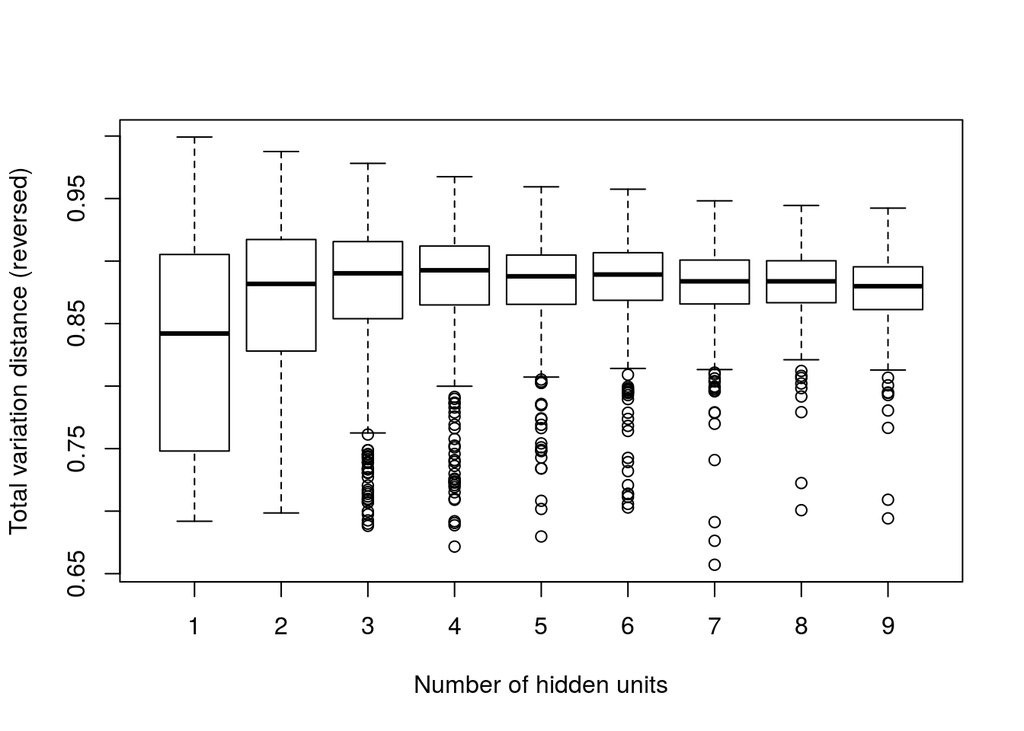

```r
boxplot(stab_tune, xlab = "Number of hidden units")
```

The `accuracy()` function provides measures of accuracy that may be useful for comparison.

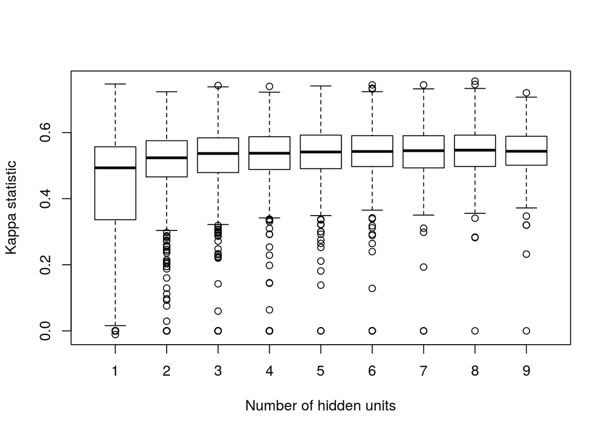

```r
acc_tune <- accuracy(stab_tune)
boxplot(acc_tune, xlab = "Number of hidden units", ylab = "Kappa statistic")
```

## Special topics

### Changing the framework settings

The number of repetitions ($B$), the similarity measure, the resampling and evaluation scheme and more settings of the framework can be modified via the `stab_control()` function in combination with the `control` argument in the function `stability()`:

```r
stability(res1, control = stab_control(...))
```

The default choice of the number of repetitions during the resampling process is $B = 500$. It may be changed to any positive integer by using

```r
stab_control(B = 1000)
```

The default choice of the similarity measure is the *Total variation distance* (TVD) for classification problems and the *Euclidean distance* (ED) for regression problems. It may be changed to other measures using

```r
stab_control(measure = list(bdist, hdist))
```

A list of similarity measures implemented in the package can be found in the documentation (via `?similarity_measures`). However, user-defined similarity functions are also accepted. For details, see the description in `?stability`.

The default combination of sampling and evaluation methods is bootstrap sampling with out-of-bag evaluation. The methods can be changed by the `control` argument. For bootstrap sampling with in-sample or out-of-sample evaluation use one of

```r
stab_control(evaluate = "ALL")
stab_control(evaluate = "OOS")
```

For subsampling with out-of-bag, in-sample or out-of-sample evaluation use one of

```r
stab_control(sampler = subsampling)
stab_control(sampler = subsampling, evaluate = "ALL")
stab_control(sampler = subsampling, evaluate = "OOS")
```

For splithalf sampling with in-sample or out-of-sample evaluation use one of

```r
stab_control(sampler = splithalf, evaluate = "ALL")
stab_control(sampler = splithalf, evaluate = "OOS")
```

More details on the available resampling and evaluation methods and all other options can be found via `?stab_control`.

### Define new algorithms

Algorithms that are not per default defined in the package **stablelearner** (see `?LearnerList` for a list of currently specified learners) can be easily added to the library during a running R session as demonstrated below. To investigate the stability of a result generated by the support vector machine algorithm implemented in the package **e1071** the following steps are necessary.

First, load the package and generate a result by:

```r
library("e1071")
res <- svm(Species ~ ., data = iris, probability = TRUE, gamma = 0.5, cost = 4)
```

Add the algorithm to `LearnerList` for the current R session by specifying the class, the package name, the name of the method, the prediction function and (optionally) an update function:

```r
newlearner <- list(
  class   = "svm",
  package = "e1071",
  method  = "Support Vector Machine",
  predfun = function(x, newdata, yclass = NULL) {
    if(match(yclass, c("ordered", "factor"))) {
      attr(predict(x, newdata = newdata, probability = TRUE), "probabilities")
    } else {
      predict(x, newdata = newdata)
    }
  },
  updatefun = NULL)
addLearner(newlearner)
```

The class of the fitted model object can be extracted using `class()`. In many cases, the generic method `predict()` is defined for the class, but the arguments tend to differ between implementations. For more information, the documentation of the corresponding package should be considered. The update function is not required, if the call can be extracted using `getCall()`.

Finally, the stability can be assessed as before using `stability()`. Note that **stablelearner** currently only supports algorithms that use the common R formula interface and the function `call` must be stored as part of the object generated by the algorithm, since the refitting is done via `update()` (see `?update`for details). Algorithms that do not provide the function call in the returning object are currently not supported.

### Stability assessment for a known DGP

It is possible to assess the stability for a known data-generating process (DGP) given by a function that is passed to the `data` argument. The function must return a an object of class `data.frame` containing the simulated observations.

First, a DGP-function must be defined, for example, via the predefined DGP-function for two-class problems available in the package.

```r
my_dgp <- function() dgp_twoclass(n = 100, p = 2, noise = 4, rho = 0.2)
```

Then, a first result must be generated by using the function and the algorithm of interest:

```r
res <- ctree(class ~ ., data = my_dgp())
```

Now, the result and the DGP-function are passed to the `stability()` function.

```r
stab_sim <- stability(res, data = my_dgp)
summary(stab_sim)
```

```
##
## Call:
## ctree(formula = class ~ ., data = my_dgp())
##
## Data-generating process:
##
## Similarity summary:
##
## , , Total variation distance (reversed)
##
##            5%    25%   50%   75%   95%
## constparty 0.706 0.751 0.781 0.816 0.890
```